# Validation of Perceived Stress Scale

Wondimu Ahmed, Ph.D.

9/21/2021

# **Project Overeview**

The Perceived Stress Scale (PSS, 1) is a widely used tool for for assessing subjective stress. Despite its widespread application, empirical evidence regarding its psychometric properties within adolescent populations—particularly among Black youth—remains limited. This study sought to fill that gap by evaluating the scale’s validity and reliability in this population. Specifically, it pursued three objectives: (1) to evaluate the applicability of the widely supported two-factor model(2,3) within a nationally representative sample of Black adolescents, (2) to examine its measurement invariance across gender, and (3) to assess its predictive validity by analyzing the relationship between perceived stress scores and lifetime prevalence of Major Depressive Disorder (MDD).

# **Methods**

## **Participants**

This study used data from the [National Survey of American Life – Adolescent Supplement (NSAL-A)](https://www.icpsr.umich.edu/web/RCMD/studies/36380). The sample included 1,170 Black adolescents aged 13–17 (52% female).

## **Measures**

### **Perceived Stress Scale (PSS)**

The study used the 14-item PSS from the NSAL-A, which included 8 positive and 6 negative items, with one item rephrased positively. Adolescents rated their perceived stress over the past month on a 5-point scale from 1 (never) to 5 (very often). To align with prior research, responses were recoded to a 0–4 scale.

### **Major Depressive Disorder (MDD)**

MDD was assessed using the World Mental Health Composite International Diagnostic Interview (CIDI) (4).

## **Statistical Analyses**

### **Factor Structure**

Confirmatory Factor Analysis (CFA) was performed to assess the factor structure of the PSS. We evaluated both one-factor and correlated two-factor models for the 14-item and 10-item versions. Model fit was evaluated using established indices: CFI and TLI (values > 0.95 indicate good fit), RMSEA (< 0.05 indicates good fit), and SRMR (< 0.05 indicates good fit).

### **Measurement Invariance**

The study tested whether the structure of the PSS worked the same way for both males and females. We checked:

- *Configural invariance* (whether the scale measured stress similarly).
- *Metric invariance* (whether the questions were understood the same way).
- *Scalar invariance* (whether responses could be compared directly).

### **Predictive Validity**

The study evaluated how well the PSS could identify adolescents with MDD using ROC curve analysis.

# **Data Preparation**

- Missing values coded as 8 and 9 in the database were replaced with NA to ensure accurate handling.
- Positively worded items were reverse-scored for consistency with negatively worded items.
- Descriptive statistics were calculated for key variables to detect anomaly ( see Table 1).
- Correlation matrix was visualized through a heatmap to examine correlation patterns( see Figure 1).
- Missing data percentages were computed and visualized to identify variables with the most missing values ( see Figure 2).

|  | Mean | SD | Median | Min | Max |
| --- | --- | --- | --- | --- | --- |
| SEX | 1.52 | 0.5 | 2 | 1 | 2 |
| PC4A | 2.82 | 1.14 | 3 | 1 | 5 |
| PC4B | 2.22 | 1.27 | 2 | 1 | 5 |
| PC4C | 2.55 | 1.25 | 3 | 1 | 5 |
| PC4D | 2.49 | 1.18 | 2 | 1 | 5 |
| PC4E | 2.09 | 1.02 | 2 | 1 | 5 |
| PC4F | 1.94 | 1 | 2 | 1 | 5 |
| PC4G | 2.47 | 1.1 | 3 | 1 | 5 |
| PC4H | 2.77 | 1.07 | 3 | 1 | 5 |
| PC4I | 2.36 | 1.04 | 2 | 1 | 5 |

[output cut: 5 more lines]

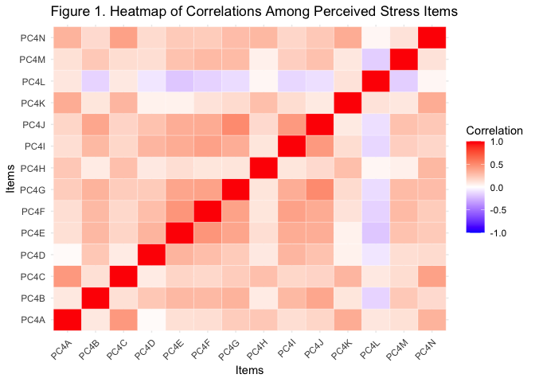

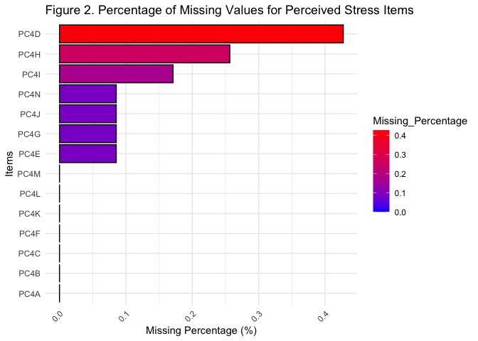

# **Results**

## **Factor Structure**

The Tables below (Tables 2 and 3) summarizes the results of the goodness-of-fit tests for the one-factor and two-factor models of the PSS-14 and PSS-10.

|  | CFI | TLI | RMSEA | SRMR |
| --- | --- | --- | --- | --- |
| Two Factor Model-13 Items | 0.939 | 0.926 | 0.058 | 0.036 |
| Two Factor Model-14 Items | 0.903 | 0.883 | 0.069 | 0.062 |
| One Factor Model-14 Items | 0.727 | 0.677 | 0.115 | 0.096 |

|  | CFI | TLI | RMSEA | SRMR |
| --- | --- | --- | --- | --- |
| Two Factor Model-10 Items | 0.964 | 0.952 | 0.053 | 0.031 |
| One Factor Model-10 Items | 0.716 | 0.634 | 0.145 | 0.104 |

#### Figure 3. Path Diagram of the Two-Factor Model (PSS-13)

[interactive chart not shown]

#### Figure 4. Path Diagram of the Two-Factor Model (PSS-10)

[interactive chart not shown]

## **Measurement Invariance**

|  | CFI | TLI | RMSEA | SRMR |
| --- | --- | --- | --- | --- |
| Configural | 0.99 | 0.988 | 0.038 | 0.043 |
| Metric | 0.988 | 0.987 | 0.04 | 0.046 |
| Scalar | 0.988 | 0.989 | 0.036 | 0.045 |

|  | ΔCFI | ΔTLI | ΔRMSEA | ΔSRMR |
| --- | --- | --- | --- | --- |
| Metric Vs.Configural | -0.002 | -0.001 | 0.002 | 0.003 |
| Scalar Vs.Metric | -0.001 | 0.002 | -0.004 | -0.001 |

|  | CFI | TLI | RMSEA | SRMR |
| --- | --- | --- | --- | --- |
| Configural | 0.994 | 0.992 | 0.032 | 0.038 |
| Metric | 0.992 | 0.99 | 0.035 | 0.042 |
| Scalar | 0.991 | 0.992 | 0.032 | 0.041 |

|  | ΔCFI | ΔTLI | ΔRMSEA | ΔSRMR |
| --- | --- | --- | --- | --- |
| Metric Vs.Configural | -0.002 | -0.002 | 0.004 | 0.004 |
| Scalar Vs.Metric | -0.001 | 0.002 | -0.004 | -0.002 |

## **Predictive Validity**

The Perceived Stress Scale (PSS) showed moderate success in identifying teens at risk for depression(See Roc Curves below). Among the study group, 7.5% were diagnosed with depression, and the PSS-13 and PSS-10 versions both performed reasonably well in distinguishing these individuals. The “perceived distress” part of the scale was particularly effective.

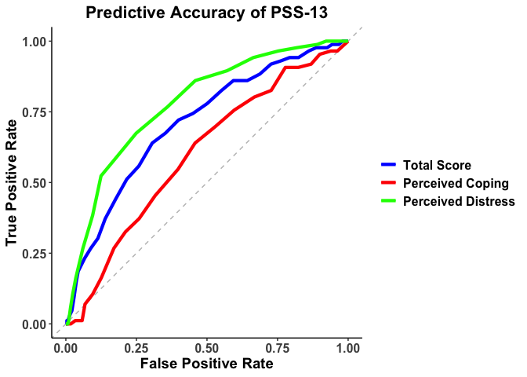

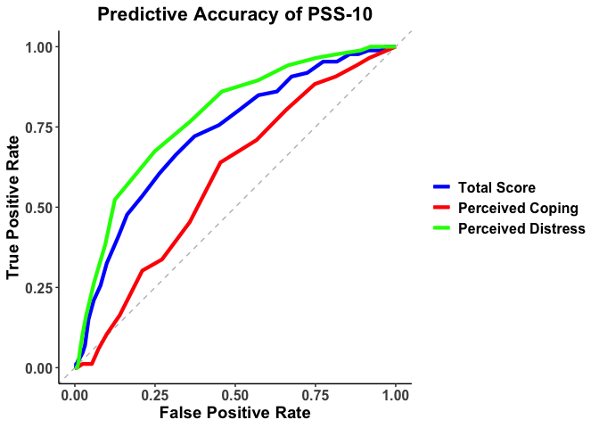

# **Implications**

These findings have important implications for both researchers and clinicians working with this population:

# **References**

1. Cohen, S., Kamarch, T., & Mermelstein, R. (1983). A global measure of perceived stress. *Journal of Health and Social Behavior*, 24, 385–396.
2. Hewitt, P. L., Flett, G. L., & Mosher, S. W. (1992). The perceived stress scale: Factor structure and relation to depression symptoms in a psychiatric sample. *Journal of Psychopathology and Behavioral Assessment*, 14(3), 247–257. https://doi.org/10.1007/BF00962631
3. Roberti, J. W., Harrington, L. N., & Storch, E. A. (2006). Further psychometric support for the 10-item version of the perceived stress scale. *Journal of College Counseling*, 9(2), 135–147. https://doi.org/10.1002/j.2161-1882.2006.tb00100.x
4. Wittchen, H. U. (1994). Reliability and validity studies of the WHO–Composite International Diagnostic Interview (CIDI): A critical review. *Journal of Psychiatric Research*, 28(1), 57–84. https://doi.org/10.1016/0022-3956(94)90036-1
5. Arnett, J. J. (1999). Adolescent storm and stress, reconsidered. *The American Psychologist*, 54(5), 317–326. https://doi.org/10.1037//0003-066x.54.5.317

Back to Top

[Back to Portfolio](https://wondimuahmed.github.io/Portfolio/)